# Homework 6

PSTAT 131/231

## Tree-Based Models

For this assignment, we will continue working with the file `"pokemon.csv"`, found in `/data`. The file is from Kaggle: https://www.kaggle.com/abcsds/pokemon.

The [Pokémon](https://www.pokemon.com/us/) franchise encompasses video games, TV shows, movies, books, and a card game. This data set was drawn from the video game series and contains statistics about 721 Pokémon, or “pocket monsters.” In Pokémon games, the user plays as a trainer who collects, trades, and battles Pokémon to (a) collect all the Pokémon and (b) become the champion Pokémon trainer.

Each Pokémon has a [primary type](https://bulbapedia.bulbagarden.net/wiki/Type) (some even have secondary types). Based on their type, a Pokémon is strong against some types, and vulnerable to others. (Think rock, paper, scissors.) A Fire-type Pokémon, for example, is vulnerable to Water-type Pokémon, but strong against Grass-type.

The goal of this assignment is to build a statistical learning model that can predict the **primary type** of a Pokémon based on its generation, legendary status, and six battle statistics.

**Note: Fitting ensemble tree-based models can take a little while to run. Consider running your models outside of the .Rmd, storing the results, and loading them in your .Rmd to minimize time to knit.**

### Exercise 1

Read in the data and set things up as in Homework 5:

- Use `clean_names()`

```r
Pokémon = clean_names(Pokémon)
```

- Filter out the rarer Pokémon types

```r
Pokémon = Pokémon[Pokémon$type_1 %in% c('Bug', 'Fire', 'Grass', 'Normal', 'Water', 'Psychic'),]
```

- Convert `type_1` and `legendary` to factors

```r
Pokémon$type_1 = as.factor(Pokémon$type_1)
Pokémon$legendary = as.factor(Pokémon$legendary)
Pokémon$generation = factor(Pokémon$generation)
```

Do an initial split of the data; you can choose the percentage for splitting. Stratify on the outcome variable.

```r
set.seed(91362)
Pokémon_split <- initial_split(Pokémon, prop = 0.70, strata = type_1)
Pokémon_train <- training(Pokémon_split)
Pokémon_test <- testing(Pokémon_split)
```

Fold the training set using *v*-fold cross-validation, with `v = 5`. Stratify on the outcome variable.

```r
set.seed(345)
Pokémon_folds <- vfold_cv(Pokémon_train, strata = type_1, v = 5)
```

Set up a recipe to predict `type_1` with `legendary`, `generation`, `sp_atk`, `attack`, `speed`, `defense`, `hp`, and `sp_def`: - Dummy-code `legendary` and `generation`; - Center and scale all predictors.

```r
Pokémon_train_recipe <- recipe(type_1 ~ legendary + generation + sp_atk + attack + speed + defense + hp + sp_def, data = Pokémon_train) %>%
  step_dummy(all_nominal_predictors()) %>%
  step_normalize(all_numeric_predictors())
```

### Exercise 2

Create a correlation matrix of the training set, using the `corrplot` package. *Note: You can choose how to handle the continuous variables for this plot; justify your decision(s).*

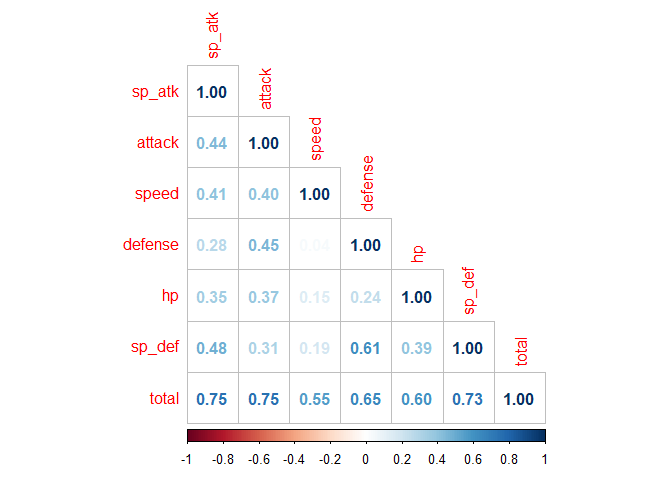

```r
Pokémon_train %>%
  select(sp_atk, attack, speed, defense, hp, sp_def, total) %>%
  cor() %>%
  corrplot(type = 'lower', diag = TRUE, method = 'number')
```

What relationships, if any, do you notice? Do these relationships make sense to you?

### Exercise 3

First, set up a decision tree model and workflow. Tune the `cost_complexity` hyperparameter. Use the same levels we used in Lab 7 – that is, `range = c(-3, -1)`. Specify that the metric we want to optimize is `roc_auc`.

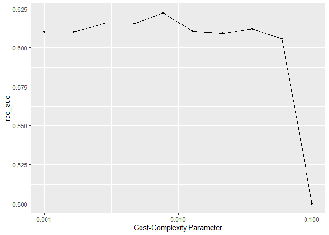

```r
tree_spec <- decision_tree() %>%
  set_engine("rpart")

class_tree_spec <- tree_spec %>%
  set_mode("classification")

class_tree_wf <- workflow() %>%
  add_model(class_tree_spec %>% set_args(cost_complexity = tune())) %>%
  add_recipe(Pokémon_train_recipe)

param_grid <-grid_regular(cost_complexity(range = c(-3, -1)), levels = 10)

tune_res <- tune_grid(
  class_tree_wf,
  resamples = Pokémon_folds,
  grid = param_grid,
  metrics = metric_set(roc_auc),
  control = control_grid(verbose = TRUE)
  )

autoplot(tune_res)
```

Print an `autoplot()` of the results. What do you observe? Does a single decision tree perform better with a smaller or larger complexity penalty?

### Exercise 4

What is the `roc_auc` of your best-performing pruned decision tree on the folds? *Hint: Use `collect_metrics()` and `arrange()`.*

```r
complexity <- arrange(collect_metrics(tune_res), desc(mean))
best_complexity <- complexity[1,]
best_complexity
```

```
## # A tibble: 1 × 7
##   cost_complexity .metric .estimator  mean     n std_err .config
##             <dbl> <chr>   <chr>      <dbl> <int>   <dbl> <chr>
## 1         0.00774 roc_auc hand_till  0.622     5  0.0160 Preprocessor1_Model05
```

### Exercise 5

Using `rpart.plot`, fit and visualize your best-performing pruned decision tree with the *training* set.

[figure not shown]

```r
class_tree_final <- finalize_workflow(class_tree_wf, best_complexity)

class_tree_final_fit <- fit(class_tree_final, data = Pokémon_train)

class_tree_final_fit %>%
  extract_fit_engine() %>%
  rpart.plot()
```

### Exercise 6

Now set up a random forest model and workflow. Use the `ranger` engine and set `importance = "impurity"`. Tune `mtry`, `trees`, and `min_n`. Using the documentation for `rand_forest()`, explain in your own words what each of these hyperparameters represent.

Create a regular grid with 8 levels each. You can choose plausible ranges for each hyperparameter.

```r
tune_grid <- grid_regular(mtry(range = c(1, 8)), trees(range = c(1,500)), min_n(range = c(1,8)), levels = 8)
```

Note that `mtry` should not be smaller than 1 or larger than 8. **Explain why not. What type of model would `mtry = 8` represent?** Answer: `mtry` is the number of random variables sampled. You can’t sample 0 variables and you can’t sample more variables than you have in the recipe. mtry = 8 would represent all of the variabled being used in the sampling.

### Exercise 7

Specify `roc_auc` as a metric. Tune the model and print an `autoplot()` of the results. What do you observe? What values of the hyperparameters seem to yield the best performance?

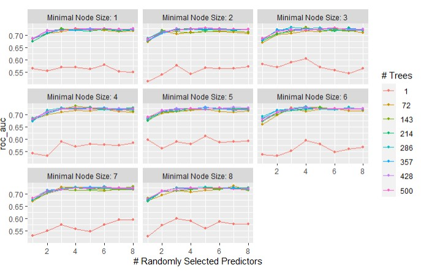

```r
tune_res2 <- tune_grid(
  object = rf_wkflow,
  resamples = Pokémon_folds,
  grid = tune_grid,
  metrics = metric_set(roc_auc),
  control = control_grid(verbose = TRUE))

autoplot(tune_res2)
```

### Exercise 8

What is the `roc_auc` of your best-performing random forest model on the folds? *Hint: Use `collect_metrics()` and `arrange()`.*

```r
best_rf <- rf_metrics[1,]
best_rf
```

```
## # A tibble: 1 × 9
##    mtry trees min_n .metric .estimator  mean     n std_err .config
##   <dbl> <dbl> <dbl> <chr>   <chr>      <dbl> <dbl>   <dbl> <chr>
## 1     4   143     4 roc_auc hand_till  0.734     5  0.0107 Preprocessor1_Model2…
```

### Exercise 9

Create a variable importance plot, using `vip()`, with your best-performing random forest model fit on the *training* set.

Which variables were most useful? Which were least useful? Are these results what you expected, or not?

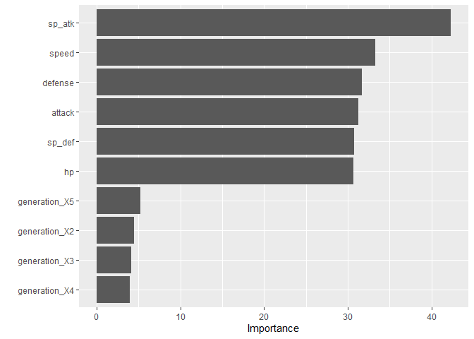

```r
rf_final <- finalize_workflow(rf_wkflow, best_rf)

rf_final_fit <- fit(rf_final, data = Pokémon_train)

rf_final_fit %>%
  pull_workflow_fit() %>%
  vip()
```

Answer: The most useful variable is `sp_atk`, while the least useful variables were `generation` and `legendary`, the later of which seems to be absent from the plot as I expected due to it only applying to a small fraction of all Pokemon while the former does not have any noticeable effect on the other variables.

### Exercise 10

```r
library(xgboost)

boost_spec <- boost_tree(trees = tune())%>%
  set_engine("xgboost") %>%
  set_mode("classification")

boost_wkflow <- workflow() %>%
  add_model(boost_spec) %>%
  add_recipe(Pokémon_train_recipe)

boost_grid <- grid_regular(trees(range=c(10, 2000)), levels = 10)
```

```r
boost_res <- tune_grid(
  object = boost_wkflow,
  resamples = Pokémon_folds,
  grid = boost_grid,
  metrics = metric_set(roc_auc),
  control = control_grid(verbose = TRUE))
```

What is the `roc_auc` of your best-performing boosted tree model on the folds? *Hint: Use `collect_metrics()` and `arrange()`.*

```r
best_boost <- boost_metrics[1,]
best_boost
```

```
## # A tibble: 1 × 7
##   trees .metric .estimator  mean     n std_err .config
##   <dbl> <chr>   <chr>      <dbl> <dbl>   <dbl> <chr>
## 1  1115 roc_auc hand_till  0.708     5  0.0169 Preprocessor1_Model06
```

### Exercise 11

Display a table of the three ROC AUC values for your best-performing pruned tree, random forest, and boosted tree models. Which performed best on the folds? Select the best of the three and use `select_best()`, `finalize_workflow()`, and `fit()` to fit it to the *testing* set.

```r
all_best <- rbind(best_complexity[2:7], best_rf[4:9], best_boost[2:7])

all_best <- data.frame(all_best)

Method <- c("Pruned tree", "Random forest", "Boosted tree")

all_best['Method'] <- Method

all_best
```

```
##   .metric .estimator      mean n    std_err                .config
## 1 roc_auc  hand_till 0.6222688 5 0.01601021  Preprocessor1_Model05
## 2 roc_auc  hand_till 0.7336462 5 0.01072295 Preprocessor1_Model212
## 3 roc_auc  hand_till 0.7076463 5 0.01688014  Preprocessor1_Model06
##          Method
## 1   Pruned tree
## 2 Random forest
## 3  Boosted tree
```

```r
absolute_best = arrange(all_best, desc(mean))[1,]
absolute_best
```

```
##   .metric .estimator      mean n    std_err                .config
## 1 roc_auc  hand_till 0.7336462 5 0.01072295 Preprocessor1_Model212
##          Method
## 1 Random forest
```

```r
best_final <- finalize_workflow(rf_wkflow, best_rf)

best_final_fit <- fit(best_final, data = Pokémon_test)
```

Print the AUC value of your best-performing model on the testing set. Print the ROC curves. Finally, create and visualize a confusion matrix heat map.

```r
augment(best_final_fit, new_data = Pokémon_test, metric = 'roc_auc')
```

```
## # A tibble: 140 × 20
##    number name      type_1 type_2 total    hp attack defense sp_atk sp_def speed
##     <dbl> <chr>     <fct>  <chr>  <dbl> <dbl>  <dbl>   <dbl>  <dbl>  <dbl> <dbl>
##  1      3 Venusaur… Grass  Poison   625    80    100     123    122    120    80
##  2      6 Charizar… Fire   Flying   634    78    104      78    159    115   100
##  3      7 Squirtle  Water  <NA>     314    44     48      65     50     64    43
##  4      9 Blastoise Water  <NA>     530    79     83     100     85    105    78
##  5     12 Butterfr… Bug    Flying   395    60     45      50     90     80    70
##  6     14 Kakuna    Bug    Poison   205    45     25      50     25     25    35
##  7     15 Beedrill  Bug    Poison   395    65     90      40     45     80    75
##  8     15 Beedrill… Bug    Poison   495    65    150      40     15     80   145
##  9     18 Pidgeot   Normal Flying   479    83     80      75     70     70   101
## 10     18 PidgeotM… Normal Flying   579    83     80      80    135     80   121
## # … with 130 more rows, and 9 more variables: generation <fct>,
## #   legendary <fct>, .pred_class <fct>, .pred_Bug <dbl>, .pred_Fire <dbl>,
## #   .pred_Grass <dbl>, .pred_Normal <dbl>, .pred_Psychic <dbl>,
## #   .pred_Water <dbl>
```

```r
augment(best_final_fit, new_data = Pokémon_test) %>%
  roc_auc(truth = type_1, estimate = c(.pred_Fire, .pred_Bug, .pred_Grass, .pred_Normal, .pred_Water, .pred_Psychic))
```

```
## # A tibble: 1 × 3
##   .metric .estimator .estimate
##   <chr>   <chr>          <dbl>
## 1 roc_auc hand_till      0.563
```

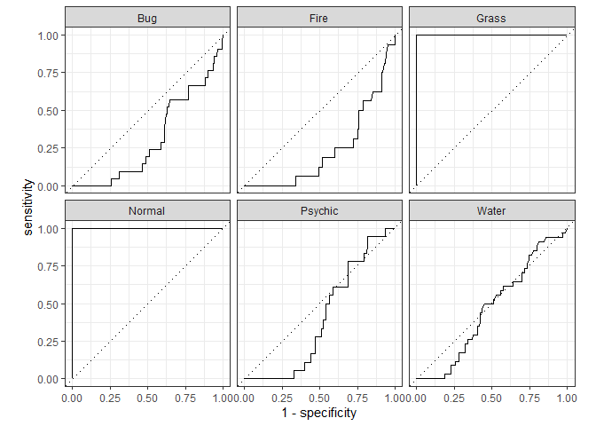

```r
augment(best_final_fit, new_data = Pokémon_test) %>%
  roc_curve(truth = type_1, estimate = c(.pred_Fire, .pred_Bug, .pred_Grass, .pred_Normal, .pred_Water, .pred_Psychic)) %>%
  autoplot()
```

```r
augment(best_final_fit, new_data = Pokémon_test) %>%
  conf_mat(truth = type_1, estimate = .pred_class)
```

```
##           Truth
## Prediction Bug Fire Grass Normal Psychic Water
##    Bug      21    0     0      0       0     0
##    Fire      0   16     0      0       0     1
##    Grass     0    0    21      0       0     0
##    Normal    0    0     0     30       0     0
##    Psychic   0    0     0      0      18     0
##    Water     0    0     0      0       0    33
```

[figure not shown]

```r
augment(best_final_fit, new_data = Pokémon_test) %>%
  conf_mat(truth = type_1, estimate = .pred_class) %>%
  autoplot()
```

Which classes was your model most accurate at predicting? Which was it worst at? Answer: It was most accurate at predicting normal types and least accurate predicting water types.

## For 231 Students

### Exercise 12

Using the `abalone.txt` data from previous assignments, fit and tune a random forest model to predict `age`. Use stratified cross-validation and select ranges for `mtry`, `min_n`, and `trees`. Present your results. What was the model’s RMSE on your testing set?

```r
abalone <- read_csv("abalone.csv")

abalone['age'] = abalone['rings'] + 1.5
```

```r
set.seed(91362)
abalone_split <- initial_split(abalone, prop = 0.80, strata = 'age')
abalone_train <- training(abalone_split)
abalone_test <- testing(abalone_split)

set.seed(345)
abalone_folds <- vfold_cv(abalone_train, strata = age, v = 5)

abalone_recipe <- recipe(age ~ type + longest_shell + diameter + height + whole_weight + shucked_weight + viscera_weight + shell_weight, data = abalone_train) %>%
  step_dummy(all_nominal_predictors()) %>%
  step_interact(terms = ~ shucked_weight:shell_weight) %>%
  step_interact(terms = ~ starts_with('type'):shucked_weight) %>%
  step_interact(terms = ~longest_shell:diameter) %>%
  step_normalize(all_predictors())

library(randomForest)

abalone_spec <- rand_forest(mtry = tune(), trees = tune(), min_n = tune()) %>%
  set_engine("ranger", importance = "impurity") %>%
  set_mode("regression")

abalone_wkflow <- workflow() %>%
  add_model(abalone_spec) %>%
  add_recipe(abalone_recipe)

abalone_grid <- grid_regular(mtry(range = c(1, 8)), trees(range = c(1,500)), min_n(range = c(1,8)), levels = 5)
```

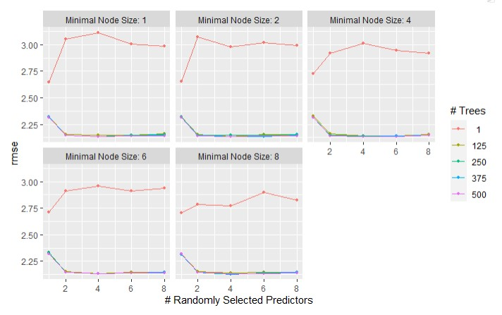

```r
abalone_res <- tune_grid(
  object = abalone_wkflow,
  resamples = abalone_folds,
  grid = abalone_grid,
  metrics = metric_set(rmse),
  control = control_grid(verbose = TRUE))

autoplot(abalone_res)
```

```r
abalone_metrics <- read_csv("abalone_metrics.csv")

best_abalone <- abalone_metrics[1,]

best_abalone
```

```
## # A tibble: 1 × 9
##    mtry trees min_n .metric .estimator  mean     n std_err .config
##   <dbl> <dbl> <dbl> <chr>   <chr>      <dbl> <dbl>   <dbl> <chr>
## 1     4     1     1 rmse    standard    3.11     5  0.0791 Preprocessor1_Model0…
```

```r
abalone_final <- finalize_workflow(abalone_wkflow, best_abalone)

abalone_final_fit <- fit(abalone_final, data = abalone_train)

augment(abalone_final_fit, new_data = abalone_test, metric = 'rmse')
```

```
## # A tibble: 837 × 11
##    type  longest_shell diameter height whole_weight shucked_weight
##    <chr>         <dbl>    <dbl>  <dbl>        <dbl>          <dbl>
##  1 F             0.545    0.425  0.125        0.768          0.294
##  2 M             0.43     0.35   0.11         0.406          0.168
##  3 M             0.5      0.4    0.13         0.664          0.258
##  4 F             0.56     0.44   0.14         0.928          0.382
##  5 M             0.58     0.47   0.165        0.998          0.394
##  6 F             0.68     0.55   0.175        1.80           0.815
##  7 F             0.54     0.475  0.155        1.22           0.530
##  8 M             0.355    0.29   0.09         0.328          0.134
##  9 F             0.45     0.335  0.105        0.425          0.186
## 10 F             0.55     0.425  0.135        0.852          0.362
## # … with 827 more rows, and 5 more variables: viscera_weight <dbl>,
## #   shell_weight <dbl>, rings <dbl>, age <dbl>, .pred <dbl>
```

```r
augment(abalone_final_fit, new_data = abalone_test) %>%
  rmse(truth = age, estimate = .pred)
```

```
## # A tibble: 1 × 3
##   .metric .estimator .estimate
##   <chr>   <chr>          <dbl>
## 1 rmse    standard        3.05
```